# Data Wrangling Project Part 2

Part 2 created using the Distill format.

Yoojin Seo A0194621E and Ling Jun Wei(A0180339A) (National University of Singapore (NUS))https://bschool.nus.edu.sg/  
2021-10-02

## Using DuckDB Register

```r
con1<-dbConnect(duckdb::duckdb(), dbdir=":memory:", read_only=FALSE)
df_host_new <- read_csv("df_host_new.csv")
df_new_listing <- read_csv("df_new_listing.csv")
dbWriteTable(con1, "host_info", df_host_new)
dbWriteTable(con1, "listing", df_new_listing)
```

## Common Room Type

Let’s start with our first question, what is the most common room type and property type available? We can acquire this information from the listing table.

First, let’s check how many room listing we have. We can use COUNT(*) to get the number of data/rows from the table listing. We rename the result as frequency.

```r
dbGetQuery(con1, "SELECT COUNT(*) as frequency FROM listing")
```

```
  frequency
1     19289
```

Now let’s check the number of data for each Room type.

```r
out_db<-dbGetQuery(con1, "SELECT room_type,COUNT(*) as frequency
                   FROM listing
                   GROUP BY room_type
                   ORDER BY COUNT(*) DESC")

head(out_db)
```

```
        room_type frequency
1 Entire home/apt     10534
2    Private room      7014
3      Hotel room      1014
4     Shared room       727
```

Let’s create a simple bar chart to visualize this result. We will use ggplot to create the plot.

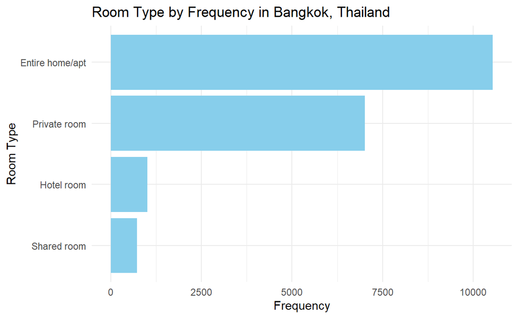

```r
out_db %>%
  ggplot(aes(x = frequency,
             y = room_type %>% reorder(frequency))
         ) +
  geom_col(fill = "skyblue") +
  labs(x = "Frequency",
       y = "Room Type",
       title = "Room Type by Frequency in Bangkok, Thailand")
```

The most common listing available is either entire home or apartment, followed by private room. Some hotels are also listing their room in Airbnb apparently.

## Common Property Type

Let’s get the top 15 property type from the data. Property type is the more granular and more detailed version from the room type.

We can use the COUNT(*) to count the number of rows and use GROUP BY to group the data based on the property type. To get the top 15, we need to arrange the data by using ORDER BY and set the sorting to descending (from largest to smallest) using the DESC. Finally, we limit the data to take only the first 15 row using the LIMIT.

```r
out_db<- dbGetQuery(con1,
                   "SELECT property_type, COUNT(*) as frequency
                   FROM listing
                   GROUP BY property_type
                   ORDER BY COUNT(*) DESC
                   LIMIT 15"
                   )

head(out_db)
```

```
                property_type frequency
1            Entire apartment      5102
2          Entire condominium      3679
3   Private room in apartment      2057
4 Private room in condominium       971
5       Private room in house       767
6      Room in boutique hotel       692
```

Let’s create a simple bar chart to visualize this result. We will use ggplot to create the plot.

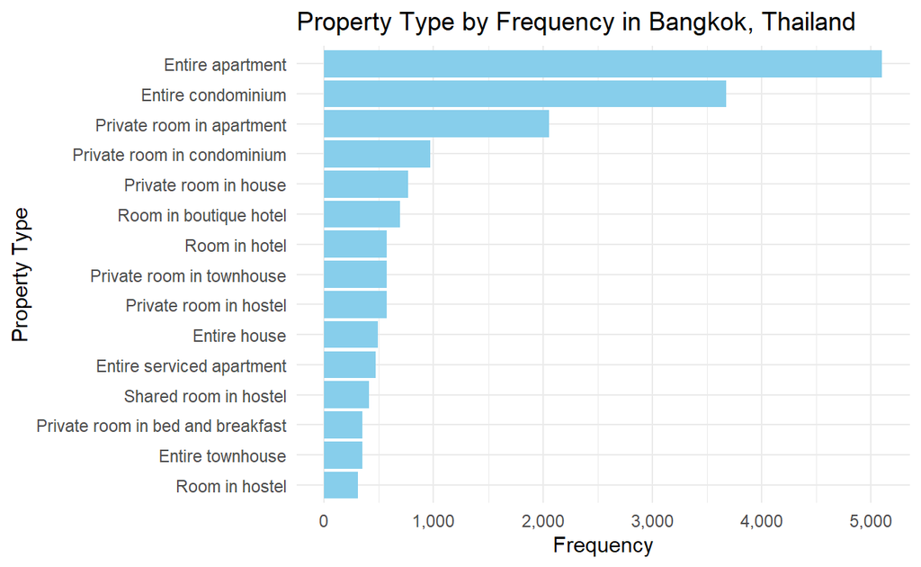

```r
library(scales)
out_db %>%
  ggplot(aes(x = frequency,
             y = property_type %>% reorder(frequency))
         ) +
  geom_col(fill = "skyblue") +
  labs(x = "Frequency",
       y = "Property Type",
       title = "Property Type by Frequency in Bangkok, Thailand") +
  scale_x_continuous(labels = number_format(big.mark = ","))
```

## Property Type by Average Price

Does apartment and condominium become popular choice because they are the cheapest option out there for the host to offer? To answer this question, let’s check the top 10 and bottom 10 property type based on the average price for a property type with at least 50 different listings.

```r
# Top 10 Property Based on Price
df_top10<- dbGetQuery(con1,
                    "SELECT property_type, average_price, frequency
                   FROM
                      (SELECT property_type,
                      AVG(price) as average_price,
                      COUNT(*) as frequency
                      FROM listing
                      GROUP BY property_type
                      ) as new_table
                   WHERE frequency >= 50
                   ORDER BY average_price DESC
                   LIMIT 10"
                   )

df_top10 <- df_top10 %>%
  mutate(type = "Top 10")

# Bottom 10 Property Based on Price
df_bottom10 <-dbGetQuery(con1,
                    "SELECT property_type, average_price, frequency
                   FROM
                      (SELECT property_type,
                      AVG(price) as average_price,
                      COUNT(*) as frequency
                      FROM listing
                      GROUP BY property_type
                      ) as new_table
                  WHERE frequency >= 50
                  ORDER BY average_price
                  LIMIT 10"
                   )

df_bottom10 <- df_bottom10 %>%
  mutate(type = "Bottom 10")

#Bind row the data frame
df_price_rank <- df_top10 %>%
  bind_rows(df_bottom10)
```

Let’s visualize the data.

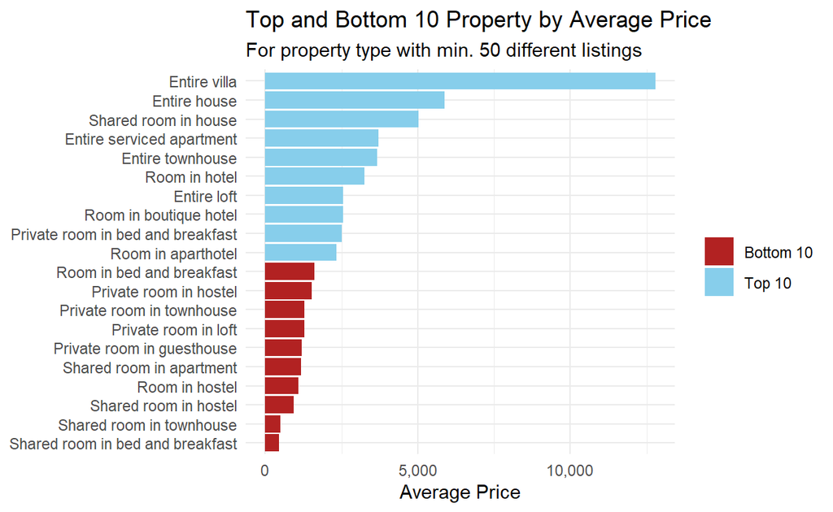

```r
df_price_rank %>%
  ggplot(aes(x = average_price,
             y = property_type %>% reorder(average_price), fill=type)
         ) +
  geom_col() +
  scale_fill_manual(values = c("firebrick", "skyblue")) +
  labs(x = "Average Price",
       y = NULL,
       fill = NULL,
       title = "Top and Bottom 10 Property by Average Price",
       subtitle = "For property type with min. 50 different listings") +
  scale_x_continuous(labels = number_format(big.mark = ","))
```

The most expensive property that is being listed is the entire villa, followed by entire house. Surprisingly, shared room in house has higher average price compared to other property. Meanwhile, on the bottom 10 the list is dominated by listing for private and shared room. However, we don’t see listing for private room or entire apartment/condominium in the top and bottom 10, so we may conclude that the price for those listings is somewhere in the middle.

## Property type by review score

According to Airbnb, there are several star ratings available for the user to measure how good the service given by the listing. Several rating that we can use including:

Overall experience: How was it? Cleanliness: Did the place meet our standards? Accuracy: Was it accurately represented with up-to-date photos and info? Check-in: Should be easy Communication: Did the Host respond to messages promptly? Location: Was the guest made aware of safety, transportation, points of interest and special considerations like noise or other situations that might affect their stay? Value: Was it worth the price? First, let’s check if there are significant difference in average of rating of the overall experience for certain property type. Some listing may don’t have any rating yet, so we will filter data that has non-NULL rating and select only property type with at least 50 different listing.